# Quality control

Andrea Villanueva Raisman

```r
library(dplyr)
library(tidyverse)
library(readxl)
library(ggplot2)
library(ggpubr)
library(ggrepel)
library(modelr)
library(HarmonizR)
```

# Introduction

# Data distribution and outliers

The exploratory analysis begins with the quality control using these in-house plasma replicates. Using both histograms and a boxplots provides complementary insights. The objective of this report is to visually explore, on the one hand, the characteristics of the raw data (e.g., distribution, outliers, batch effects) and, on the other, the effects of filtering the data by comparing the boxplots and histograms before and after filtering. This should also provide some insight into potential problems and the source of technical variability.

By looking at the total area of the peptide intensity peaks in the histogram, it is possible to assess if they follow a normal distribution. The first histogram, which belongs to the raw data, has a smaller median because it has a higher proportion of low values for the Total Peak Areas. As expected, once the data is filtered, many of the peaks with the smaller areas are removed because they belonged to low-quality peptides which have now been excluded.

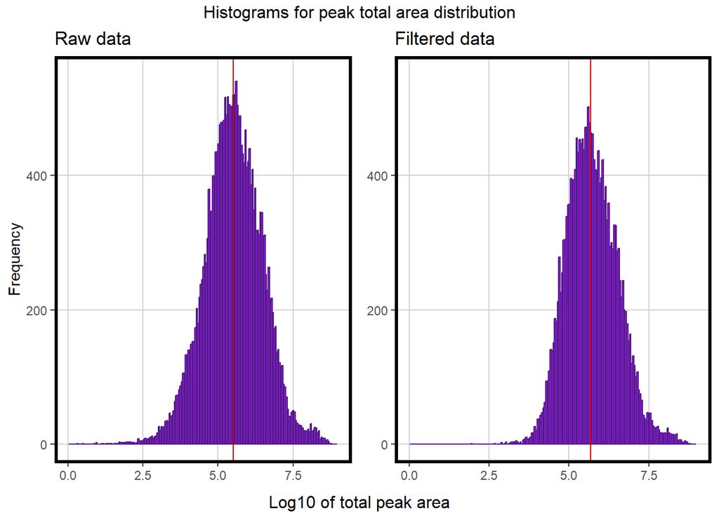

Boxplots show the data distribution per plate and the identification of outliers, making it easier to compare the data across the plates. Thus, it can also be a first approach to detecting strong batch effects. The outliers shown by the boxplot can be the result of bad peak integration. In some cases, this can be the result of incorrect peak integration which can be corrected manually. However, this is not always the case. There are times in which heavy isotopes are not detected and there is no information to improve the integration.

After filtering out low-quality peptides, the most notorious outliers, especially the ones tending to zero because of missing heavy isotopes have disappeared. What becomes aparent now is that there are some wells with much lower medians. Medians can be a robust measure for comparing samples due to their resistance to outliers -unlike means- and their ability to represent the central tendency of the data. Thus, in relatively large datasets like this one, such changes in the median between replicates can indicate bias that comes from technical variability.

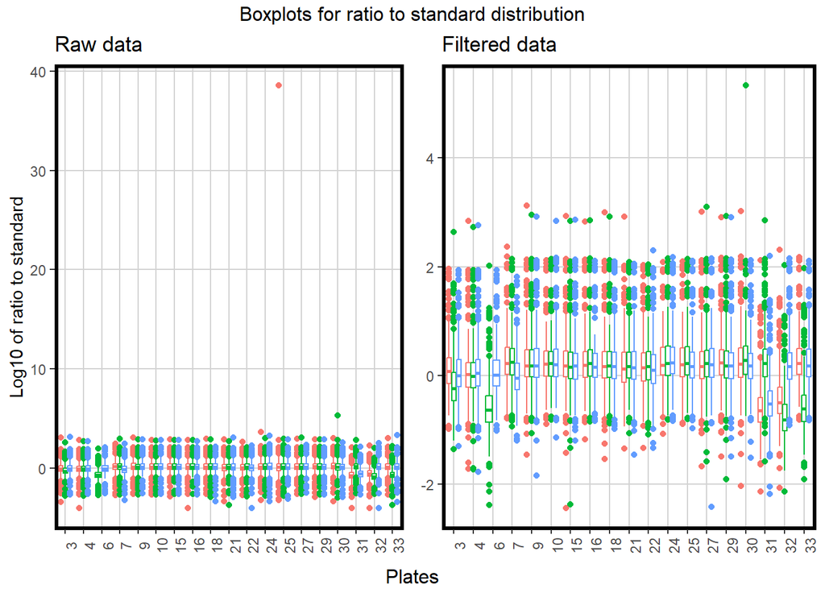

# Peptide quantification inter-plate comparisons: APOA1 and VTCN

Another way to look into technical variability is by using reference proteins like APOA1 and VTNC, which are very stable, well-characterized and commonly measured in blood. These characteristics make them suitable to ensure consistency and reliability in proteomic experiments, especially when comparing results across plates.

The graphs to the right take APOA1’s and VTNC’s peptides with the smallest CV and trace a line that follows the same well between plates. This was an attempt to see if all the data points belonging to samples 31 to 33 at the bottom of the graph had been in the same well. In this case, the problem would have still been relatively easy to solve by batch correction. Both proteins follow a very similar pattern.

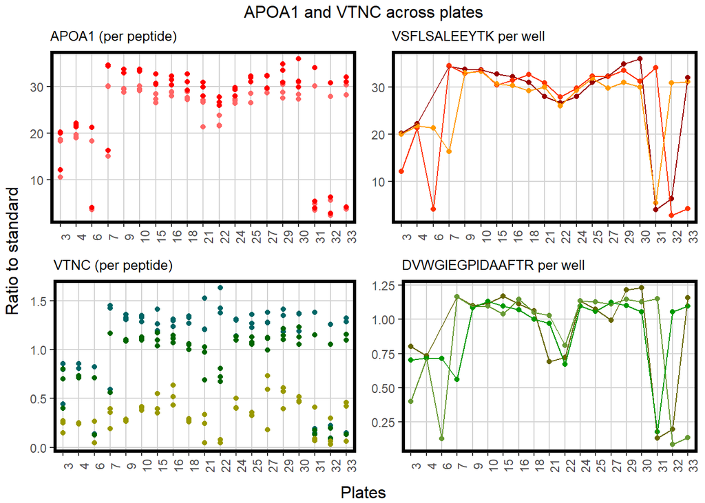

# Correlation between APOA1 and VTNC

To confirm this further, both proteins are plotted to see the correlation of their medians. As mentioned before, medians are robust to outliers. The correlation between both proteins’s medians across plates is close to 1, confirming that they do follow the same pattern. This format also allows us to see plates that might have another type of problem that might not be aparent in the graphs before. It is also possible to use the peptide with the smallest CV instead of the median. When comparing the correlation between two proteins, choosing the smallest peptide coefficient of variation (CV) over the protein peptide median can offer specific advantages. Focusing on the peptide with the smallest CV provides insight into the behaviors or relationships that are more stable across conditions. In this case, the result is almost identical.

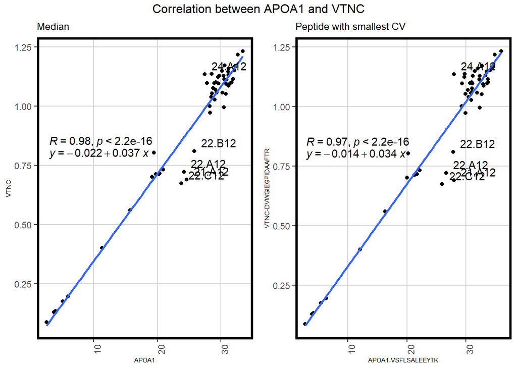

# Conclusions